# Supervised Learning - Foundations Project: ReCell

## Problem Statement

### Business Context

Buying and selling used phones and tablets used to be something that happened on a handful of online marketplace sites. But the used and refurbished device market has grown considerably over the past decade, and a new IDC (International Data Corporation) forecast predicts that the used phone market would be worth \$52.7bn by 2023 with a compound annual growth rate (CAGR) of 13.6% from 2018 to 2023. This growth can be attributed to an uptick in demand for used phones and tablets that offer considerable savings compared with new models.

Refurbished and used devices continue to provide cost-effective alternatives to both consumers and businesses that are looking to save money when purchasing one. There are plenty of other benefits associated with the used device market. Used and refurbished devices can be sold with warranties and can also be insured with proof of purchase. Third-party vendors/platforms, such as Verizon, Amazon, etc., provide attractive offers to customers for refurbished devices. Maximizing the longevity of devices through second-hand trade also reduces their environmental impact and helps in recycling and reducing waste. The impact of the COVID-19 outbreak may further boost this segment as consumers cut back on discretionary spending and buy phones and tablets only for immediate needs.

### Objective

The rising potential of this comparatively under-the-radar market fuels the need for an ML-based solution to develop a dynamic pricing strategy for used and refurbished devices. ReCell, a startup aiming to tap the potential in this market, has hired you as a data scientist. They want you to analyze the data provided and build a linear regression model to predict the price of a used phone/tablet and identify factors that significantly influence it.

### Data Description

The data contains the different attributes of used/refurbished phones and tablets. The data was collected in the year 2021. The detailed data dictionary is given below.

- brand_name: Name of manufacturing brand
- os: OS on which the device runs
- screen_size: Size of the screen in cm
- 4g: Whether 4G is available or not
- 5g: Whether 5G is available or not
- main_camera_mp: Resolution of the rear camera in megapixels
- selfie_camera_mp: Resolution of the front camera in megapixels
- int_memory: Amount of internal memory (ROM) in GB
- ram: Amount of RAM in GB
- battery: Energy capacity of the device battery in mAh
- weight: Weight of the device in grams
- release_year: Year when the device model was released
- days_used: Number of days the used/refurbished device has been used
- normalized_new_price: Normalized price of a new device of the same model in euros
- normalized_used_price: Normalized price of the used/refurbished device in euros

## Importing necessary libraries

```python
# import libraries for data manipulation
import numpy as np
import pandas as pd

# import libraries for data visualization
import matplotlib.pyplot as plt
from matplotlib import pyplot
import seaborn as sns

import pylab
import scipy
import scipy.stats as stats
from sklearn.model_selection import train_test_split
from sklearn.metrics import mean_absolute_error, mean_squared_error

import statsmodels.api as sm
from statsmodels.stats.outliers_influence import variance_inflation_factor
import statsmodels.stats.api as sms
from statsmodels.compat import lzip
```

## Loading the dataset

```python
path = 'C:\\Users\\Garrett\\OneDrive\\Documents\\DS Certification\\ReCell Project\\'

# read the data
df = pd.read_csv(path+'used_device_data.csv')
# returns the first 5 rows
df.head()
```

|  | brand_name | os | screen_size | 4g | 5g | main_camera_mp | selfie_camera_mp | int_memory | ram | battery | weight | release_year | days_used | normalized_used_price | normalized_new_price |
| --- | --- | --- | --- | --- | --- | --- | --- | --- | --- | --- | --- | --- | --- | --- | --- |
| 0 | Honor | Android | 14.50 | yes | no | 13.0 | 5.0 | 64.0 | 3.0 | 3020.0 | 146.0 | 2020 | 127 | 4.307572 | 4.715100 |
| 1 | Honor | Android | 17.30 | yes | yes | 13.0 | 16.0 | 128.0 | 8.0 | 4300.0 | 213.0 | 2020 | 325 | 5.162097 | 5.519018 |
| 2 | Honor | Android | 16.69 | yes | yes | 13.0 | 8.0 | 128.0 | 8.0 | 4200.0 | 213.0 | 2020 | 162 | 5.111084 | 5.884631 |
| 3 | Honor | Android | 25.50 | yes | yes | 13.0 | 8.0 | 64.0 | 6.0 | 7250.0 | 480.0 | 2020 | 345 | 5.135387 | 5.630961 |
| 4 | Honor | Android | 15.32 | yes | no | 13.0 | 8.0 | 64.0 | 3.0 | 5000.0 | 185.0 | 2020 | 293 | 4.389995 | 4.947837 |

## Data Overview

- Observations
- Sanity checks

```python
df.shape
# The dataframe has 3454 rows and 15 columns
```

```
(3454, 15)
```

```python
df.describe(include='all')
```

|  | brand_name | os | screen_size | 4g | 5g | main_camera_mp | selfie_camera_mp | int_memory | ram | battery | weight | release_year | days_used | normalized_used_price | normalized_new_price |
| --- | --- | --- | --- | --- | --- | --- | --- | --- | --- | --- | --- | --- | --- | --- | --- |
| count | 3454 | 3454 | 3454.000000 | 3454 | 3454 | 3275.000000 | 3452.000000 | 3450.000000 | 3450.000000 | 3448.000000 | 3447.000000 | 3454.000000 | 3454.000000 | 3454.000000 | 3454.000000 |
| unique | 34 | 4 | NaN | 2 | 2 | NaN | NaN | NaN | NaN | NaN | NaN | NaN | NaN | NaN | NaN |
| top | Others | Android | NaN | yes | no | NaN | NaN | NaN | NaN | NaN | NaN | NaN | NaN | NaN | NaN |
| freq | 502 | 3214 | NaN | 2335 | 3302 | NaN | NaN | NaN | NaN | NaN | NaN | NaN | NaN | NaN | NaN |
| mean | NaN | NaN | 13.713115 | NaN | NaN | 9.460208 | 6.554229 | 54.573099 | 4.036122 | 3133.402697 | 182.751871 | 2015.965258 | 674.869716 | 4.364712 | 5.233107 |
| std | NaN | NaN | 3.805280 | NaN | NaN | 4.815461 | 6.970372 | 84.972371 | 1.365105 | 1299.682844 | 88.413228 | 2.298455 | 248.580166 | 0.588914 | 0.683637 |
| min | NaN | NaN | 5.080000 | NaN | NaN | 0.080000 | 0.000000 | 0.010000 | 0.020000 | 500.000000 | 69.000000 | 2013.000000 | 91.000000 | 1.536867 | 2.901422 |
| 25% | NaN | NaN | 12.700000 | NaN | NaN | 5.000000 | 2.000000 | 16.000000 | 4.000000 | 2100.000000 | 142.000000 | 2014.000000 | 533.500000 | 4.033931 | 4.790342 |
| 50% | NaN | NaN | 12.830000 | NaN | NaN | 8.000000 | 5.000000 | 32.000000 | 4.000000 | 3000.000000 | 160.000000 | 2015.500000 | 690.500000 | 4.405133 | 5.245892 |
| 75% | NaN | NaN | 15.340000 | NaN | NaN | 13.000000 | 8.000000 | 64.000000 | 4.000000 | 4000.000000 | 185.000000 | 2018.000000 | 868.750000 | 4.755700 | 5.673718 |
| max | NaN | NaN | 30.710000 | NaN | NaN | 48.000000 | 32.000000 | 1024.000000 | 12.000000 | 9720.000000 | 855.000000 | 2020.000000 | 1094.000000 | 6.619433 | 7.847841 |

Taking a cursory look at the data we have, it looks like there are some missing values for the camera sizes, memory, ram, battery, and weight. Some of these could be missing because the phone doesn't have a camera, but fields like weight need to be looked at because every phone, without a doubt, has weight.

Treatments will be done in a later section for missing values and for outliers.

```python
df.info()
# Plenty of null values in need of treatment, but all data types appear to make sense.
```

```
<class 'pandas.core.frame.DataFrame'>
RangeIndex: 3454 entries, 0 to 3453
Data columns (total 15 columns):
 #   Column                 Non-Null Count  Dtype
---  ------                 --------------  -----
 0   brand_name             3454 non-null   object
 1   os                     3454 non-null   object
 2   screen_size            3454 non-null   float64
 3   4g                     3454 non-null   object
 4   5g                     3454 non-null   object
 5   main_camera_mp         3275 non-null   float64
 6   selfie_camera_mp       3452 non-null   float64
 7   int_memory             3450 non-null   float64
 8   ram                    3450 non-null   float64
 9   battery                3448 non-null   float64
 10  weight                 3447 non-null   float64
 11  release_year           3454 non-null   int64
 12  days_used              3454 non-null   int64
 13  normalized_used_price  3454 non-null   float64
 14  normalized_new_price   3454 non-null   float64
dtypes: float64(9), int64(2), object(4)
memory usage: 404.9+ KB
```

```python
df['brand_name'].value_counts()
```

```
Others        502
Samsung       341
Huawei        251
LG            201
Lenovo        171
ZTE           140
Xiaomi        132
Oppo          129
Asus          122
Alcatel       121
Micromax      117
Vivo          117
Honor         116
HTC           110
Nokia         106
Motorola      106
Sony           86
Meizu          62
Gionee         56
Acer           51
XOLO           49
Panasonic      47
Realme         41
Apple          39
Lava           36
Celkon         33
Spice          30
Karbonn        29
Coolpad        22
BlackBerry     22
Microsoft      22
OnePlus        22
Google         15
Infinix        10
Name: brand_name, dtype: int64
```

```python
df['int_memory'].value_counts()
# Plenty of outliers here
```

```
16.00      1283
32.00      1083
64.00       509
128.00      372
256.00       86
512.00       44
0.06         18
0.10         17
8.00         12
4.00         10
1024.00       8
0.50          4
0.20          2
24.00         1
0.01          1
Name: int_memory, dtype: int64
```

## Exploratory Data Analysis (EDA)

- EDA is an important part of any project involving data.
- It is important to investigate and understand the data better before building a model with it.
- A few questions have been mentioned below which will help you approach the analysis in the right manner and generate insights from the data.
- A thorough analysis of the data, in addition to the questions mentioned below, should be done.

**Questions**:

1. What does the distribution of normalized used device prices look like?
2. What percentage of the used device market is dominated by Android devices?
3. The amount of RAM is important for the smooth functioning of a device. How does the amount of RAM vary with the brand?
4. A large battery often increases a device's weight, making it feel uncomfortable in the hands. How does the weight vary for phones and tablets offering large batteries (more than 4500 mAh)?
5. Bigger screens are desirable for entertainment purposes as they offer a better viewing experience. How many phones and tablets are available across different brands with a screen size larger than 6 inches?
6. A lot of devices nowadays offer great selfie cameras, allowing us to capture our favorite moments with loved ones. What is the distribution of devices offering greater than 8MP selfie cameras across brands?
7. Which attributes are highly correlated with the normalized price of a used device?

### Question #1

```
The median normalized used phone price is 4.405132623388357
```

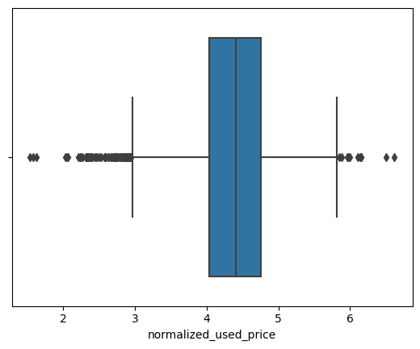

```python
# As shown in the boxplot below, the median is approximately 4.4, the min is around 3, and the max is just below 6.
# There are a large number of outliers.
print("The median normalized used phone price is",df["normalized_used_price"].median())
sns.boxplot(data=df, x="normalized_used_price");
```

### Question #2

```python
# Creating a variable for the percentage:
android_share = round((df['os'].value_counts()['Android'])/(len(df)),2)
print("Android has a used device market share of",android_share,"percent.")
```

```
Android has a used device market share of 0.93 percent.
```

### Question #3

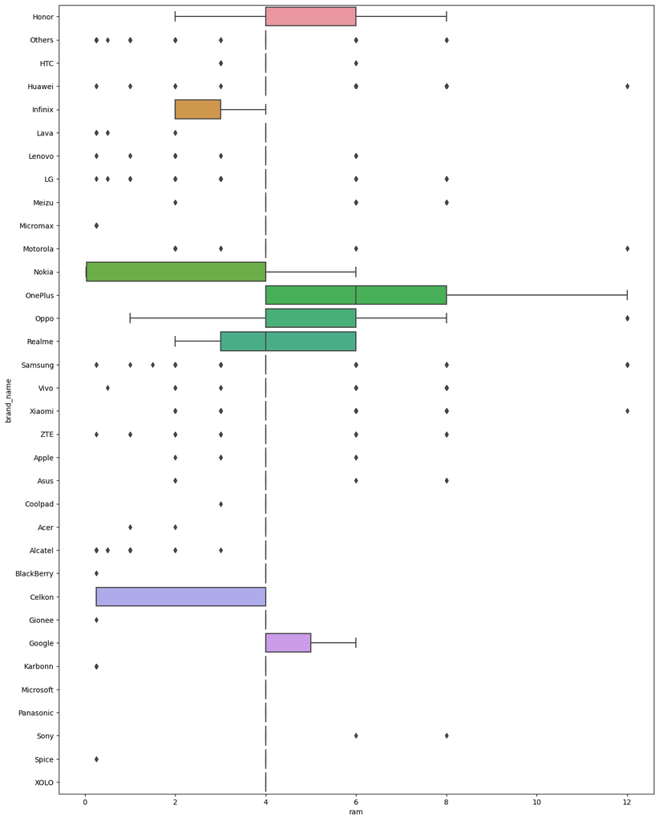

```python
# As shown in the visual below, ram is only impacted by a select few brand names.
# Infinix, Nokia, and Celkon represent low ram brands.
# Honor, OnePlus, Oppo, Realme, and Google represent high ram brands compared to the 4 ram median.
ax_dim = (15, 20)
fig, ax = pyplot.subplots(figsize=ax_dim)
sns.boxplot(data=df, y='brand_name', x='ram', ax=ax);
```

### Question #4

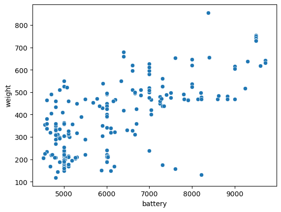

```python
# The visual below shows that the battery and weight of the phone are positively correlated for phones over 4500 mAh.
heavy_bat = df.loc[df['battery'] > 4500]
sns.scatterplot(data=heavy_bat, x='battery', y='weight');
```

### Question #5

```python
# Given that 1in is equal to 2.54cm, we need to look for phone screens larger than 15.24cm to capture all phones over 6in.
cm_meas = 6 * 2.54
# I will use a simple loop to find the count:
size_count = sum(i > cm_meas for i in df['screen_size'])
print('There are ',size_count,'phones larger than 6 inches.')
```

```
There are  1099 phones larger than 6 inches.
```

### Question #6

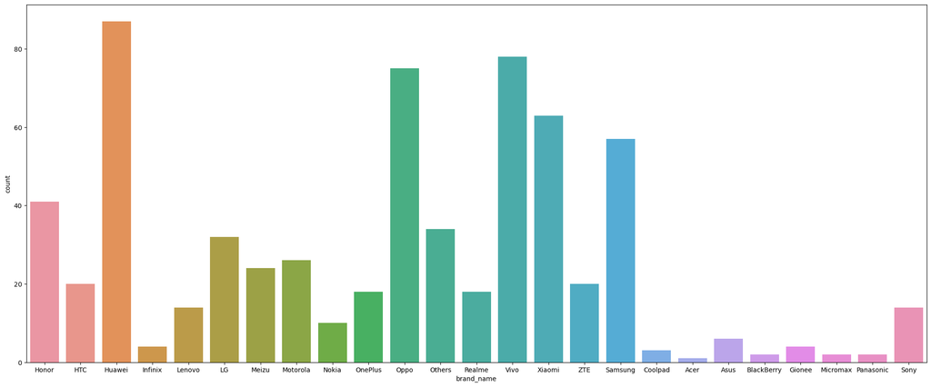

```python
# Below is a countplot showing the distribution of phones by brand for phones with a selfie camera greater than 8MP.
selfie = df.loc[df['selfie_camera_mp'] > 8]
ax_dim2 = (25, 10)
fig, ax = pyplot.subplots(figsize=ax_dim2)
sns.countplot(data=selfie,x='brand_name');
```

### Question #7

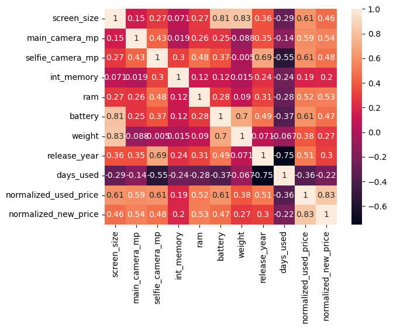

```python
# Per the heatmap below, the used phone price has a high correlation with the new phone price.
sns.heatmap(df.corr(), annot=True);
```

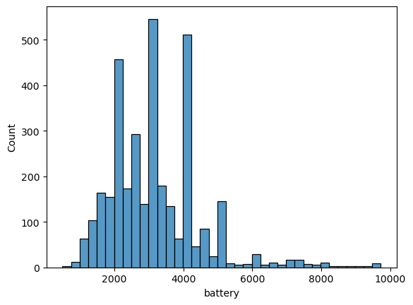

```python
# Histplot showing the distribution of battery power, very clearly right skewed.
sns.histplot(data=df, x='battery');
```

```python
# Double checking here that there are no values for release year that aren't, in fact, years.
df.value_counts('release_year')
```

```
release_year
2014    642
2013    570
2015    515
2019    446
2016    383
2018    322
2017    299
2020    277
dtype: int64
```

## Data Preprocessing

- Missing value treatment
- Feature engineering (if needed)
- Outlier detection and treatment (if needed)
- Preparing data for modeling
- Any other preprocessing steps (if needed)

```python
# Converting the 4g and 5g columns to boolean values for regression modeling.
df['4g'] = df['4g'].map({'yes': 1, 'no': 0})
df['5g'] = df['5g'].map({'yes': 1, 'no': 0})
```

```python
# There were a couple hundred null values for the main camera quality, and I opted to fill them with zeroes.
# After a quick search online, I found that there are phones sold without cameras as a feature,
# and I thought it was more accurate to denote them with zero.
df['main_camera_mp'].fillna(value=0, inplace=True)
```

```python
# The below code replaces all null values for the columns with the median value.
# I chose median because the data has some skew/outliers and doesn't follow a standard normal curve.
scam_med = df['selfie_camera_mp'].median()
df['selfie_camera_mp'].fillna(value=scam_med, inplace=True)

mem_med = df['int_memory'].median()
df['int_memory'].fillna(value=mem_med, inplace=True)

ram_med = df['ram'].median()
df['ram'].fillna(value=ram_med, inplace=True)

bat_med = df['battery'].median()
df['battery'].fillna(value=bat_med, inplace=True)

weight_med = df['weight'].median()
df['weight'].fillna(value=weight_med, inplace=True)
```

```python
# Creating dummy variables for brand name and OS:
df = pd.get_dummies(df, columns=['brand_name','os'], drop_first=True)
df.head()
```

|  | screen_size | 4g | 5g | main_camera_mp | selfie_camera_mp | int_memory | ram | battery | weight | release_year | ... | brand_name_Samsung | brand_name_Sony | brand_name_Spice | brand_name_Vivo | brand_name_XOLO | brand_name_Xiaomi | brand_name_ZTE | os_Others | os_Windows | os_iOS |
| --- | --- | --- | --- | --- | --- | --- | --- | --- | --- | --- | --- | --- | --- | --- | --- | --- | --- | --- | --- | --- | --- |
| 0 | 14.50 | 1 | 0 | 13.0 | 5.0 | 64.0 | 3.0 | 3020.0 | 146.0 | 2020 | ... | 0 | 0 | 0 | 0 | 0 | 0 | 0 | 0 | 0 | 0 |
| 1 | 17.30 | 1 | 1 | 13.0 | 16.0 | 128.0 | 8.0 | 4300.0 | 213.0 | 2020 | ... | 0 | 0 | 0 | 0 | 0 | 0 | 0 | 0 | 0 | 0 |
| 2 | 16.69 | 1 | 1 | 13.0 | 8.0 | 128.0 | 8.0 | 4200.0 | 213.0 | 2020 | ... | 0 | 0 | 0 | 0 | 0 | 0 | 0 | 0 | 0 | 0 |
| 3 | 25.50 | 1 | 1 | 13.0 | 8.0 | 64.0 | 6.0 | 7250.0 | 480.0 | 2020 | ... | 0 | 0 | 0 | 0 | 0 | 0 | 0 | 0 | 0 | 0 |
| 4 | 15.32 | 1 | 0 | 13.0 | 8.0 | 64.0 | 3.0 | 5000.0 | 185.0 | 2020 | ... | 0 | 0 | 0 | 0 | 0 | 0 | 0 | 0 | 0 | 0 |

5 rows × 49 columns

```python
df.info()
```

```
<class 'pandas.core.frame.DataFrame'>
RangeIndex: 3454 entries, 0 to 3453
Data columns (total 49 columns):
 #   Column                 Non-Null Count  Dtype
---  ------                 --------------  -----
 0   screen_size            3454 non-null   float64
 1   4g                     3454 non-null   int64
 2   5g                     3454 non-null   int64
 3   main_camera_mp         3454 non-null   float64
 4   selfie_camera_mp       3454 non-null   float64
 5   int_memory             3454 non-null   float64
 6   ram                    3454 non-null   float64
 7   battery                3454 non-null   float64
 8   weight                 3454 non-null   float64
 9   release_year           3454 non-null   int64
```

[output cut: 41 more lines]

## EDA

- It is a good idea to explore the data once again after manipulating it.

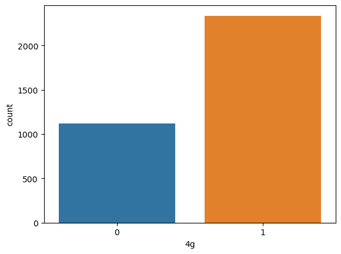

```python
sns.countplot(data=df, x='4g');
```

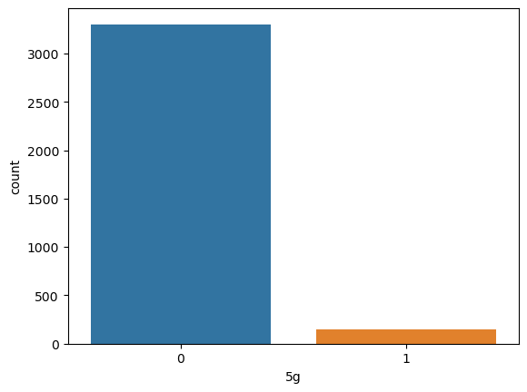

```python
sns.countplot(data=df, x='5g');
```

No issues with 4g or 5g being converted to boolean values.

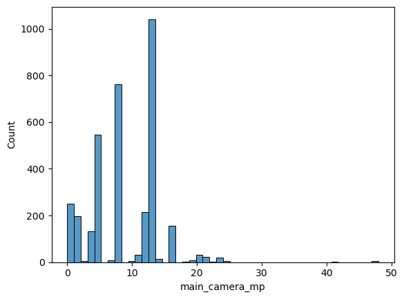

```python
sns.histplot(data=df, x='main_camera_mp');
```

Nothing stands out here with the treatment completed. The outliers are acceptable in this case as phone cameras with high quality cameras are within the realm of possibility in the year 2023. All other columns would not be heavily impacted by data cleanup.

## Model Building - Linear Regression

```python
# Creating a list of independent variables
X = df.drop(['normalized_used_price'], axis=1)
# Defining the dependent variable
y = df[['normalized_used_price']]
# Adding a constant
X = sm.add_constant(X)

X, x_test, y, y_test = train_test_split(X, y, test_size=0.3, random_state=1)
```

```python
# Creating the initial model
olsmod = sm.OLS(y, X)
olsres = olsmod.fit()
```

```python
print(olsres.summary())
```

```
                              OLS Regression Results
=================================================================================
Dep. Variable:     normalized_used_price   R-squared:                       0.843
Model:                               OLS   Adj. R-squared:                  0.840
Method:                    Least Squares   F-statistic:                     264.9
Date:                   Tue, 10 Oct 2023   Prob (F-statistic):               0.00
Time:                           13:58:13   Log-Likelihood:                 109.25
No. Observations:                   2417   AIC:                            -120.5
Df Residuals:                       2368   BIC:                             163.2
Df Model:                             48
Covariance Type:               nonrobust
=========================================================================================
                            coef    std err          t      P>|t|      [0.025      0.975]
-----------------------------------------------------------------------------------------
const                   -53.7656      9.228     -5.826      0.000     -71.862     -35.669
screen_size               0.0245      0.003      7.154      0.000       0.018       0.031
4g                        0.0553      0.016      3.460      0.001       0.024       0.087
5g                       -0.0203      0.032     -0.627      0.531      -0.084       0.043
main_camera_mp            0.0162      0.001     12.613      0.000       0.014       0.019
selfie_camera_mp          0.0139      0.001     12.301      0.000       0.012       0.016
int_memory             7.782e-05   6.99e-05      1.113      0.266   -5.93e-05       0.000
ram                       0.0238      0.005      4.602      0.000       0.014       0.034
battery               -1.287e-05    7.3e-06     -1.763      0.078   -2.72e-05    1.45e-06
weight                    0.0009      0.000      6.846      0.000       0.001       0.001
release_year              0.0273      0.005      5.962      0.000       0.018       0.036
days_used              3.482e-05   3.11e-05      1.118      0.264   -2.62e-05    9.59e-05
normalized_new_price      0.4420      0.012     36.300      0.000       0.418       0.466
brand_name_Alcatel        0.0129      0.048      0.270      0.787      -0.081       0.107
brand_name_Apple         -0.0126      0.148     -0.085      0.932      -0.303       0.278
brand_name_Asus           0.0281      0.048      0.582      0.560      -0.066       0.123
brand_name_BlackBerry     0.0022      0.071      0.032      0.975      -0.136       0.141
brand_name_Celkon        -0.0292      0.067     -0.438      0.662      -0.160       0.101
brand_name_Coolpad        0.0660      0.073      0.901      0.368      -0.078       0.210
brand_name_Gionee         0.0479      0.058      0.825      0.409      -0.066       0.162
brand_name_Google        -0.0360      0.085     -0.423      0.672      -0.203       0.131
brand_name_HTC           -0.0070      0.048     -0.144      0.885      -0.102       0.088
brand_name_Honor          0.0229      0.050      0.462      0.644      -0.074       0.120
brand_name_Huawei        -0.0136      0.045     -0.304      0.761      -0.101       0.074
brand_name_Infinix        0.2681      0.094      2.842      0.005       0.083       0.453
brand_name_Karbonn        0.1088      0.067      1.612      0.107      -0.024       0.241
```

[output cut: 19 more lines]

```
brand_name_ZTE            0.0057      0.048      0.120      0.905      -0.088       0.099
os_Others                -0.0584      0.033     -1.771      0.077      -0.123       0.006
os_Windows               -0.0135      0.045     -0.297      0.766      -0.103       0.076
os_iOS                   -0.0644      0.147     -0.437      0.662      -0.353       0.225
==============================================================================
Omnibus:                      201.668   Durbin-Watson:                   1.898
Prob(Omnibus):                  0.000   Jarque-Bera (JB):              370.051
Skew:                          -0.578   Prob(JB):                     4.41e-81
Kurtosis:                       4.529   Cond. No.                     7.68e+06
==============================================================================

Notes:
[1] Standard Errors assume that the covariance matrix of the errors is correctly specified.
[2] The condition number is large, 7.68e+06. This might indicate that there are
strong multicollinearity or other numerical problems.
```

## Model Performance Check

```python
# Setting up a VIF test to test whether or not there is Multicollinearity in the model:
vif_series1 = pd.Series([variance_inflation_factor(X.values, i) for i in range(X.shape[1])],index=X.columns,)
print("VIF values: \n\n{}\n".format(vif_series1))
```

```
VIF values:

const                    3.770145e+06
screen_size              7.680164e+00
4g                       2.475274e+00
5g                       1.901144e+00
main_camera_mp           1.939280e+00
selfie_camera_mp         2.801878e+00
int_memory               1.354692e+00
ram                      2.259077e+00
battery                  4.058583e+00
weight                   6.316696e+00
release_year             4.872005e+00
days_used                2.675619e+00
normalized_new_price     3.037893e+00
brand_name_Alcatel       3.405366e+00
brand_name_Apple         1.305828e+01
brand_name_Asus          3.328624e+00
brand_name_BlackBerry    1.633647e+00
brand_name_Celkon        1.772239e+00
brand_name_Coolpad       1.466261e+00
brand_name_Gionee        1.951131e+00
brand_name_Google        1.322273e+00
brand_name_HTC           3.408906e+00
brand_name_Honor         3.350852e+00
brand_name_Huawei        5.991045e+00
brand_name_Infinix       1.299221e+00
brand_name_Karbonn       1.571818e+00
brand_name_LG            4.846931e+00
brand_name_Lava          1.710433e+00
brand_name_Lenovo        4.558772e+00
brand_name_Meizu         2.168840e+00
brand_name_Micromax      3.363149e+00
brand_name_Microsoft     1.869325e+00
brand_name_Motorola      3.242868e+00
brand_name_Nokia         3.470627e+00
brand_name_OnePlus       1.446483e+00
brand_name_Oppo          3.973460e+00
brand_name_Others        9.709657e+00
brand_name_Panasonic     2.103742e+00
brand_name_Realme        1.973678e+00
brand_name_Samsung       7.539050e+00
brand_name_Sony          2.915157e+00
brand_name_Spice         1.688456e+00
brand_name_Vivo          3.643541e+00
brand_name_XOLO          2.135614e+00
brand_name_Xiaomi        3.703442e+00
brand_name_ZTE           3.791273e+00
os_Others                1.853466e+00
os_Windows               1.595457e+00
os_iOS                   1.178505e+01
dtype: float64
```

Looking at the VIF values above, the OS for iOS and brand name Apple appear to be the higher values, so I will test below.

```python
X2 = X.drop(['os_iOS'], axis=1)
olsmod1 = sm.OLS(y, X2)
olsres1 = olsmod1.fit()
print('Adjusted R-Squared:',np.round(olsres1.rsquared_adj, 4))
```

```
Adjusted R-Squared: 0.8399
```

```python
X3 = X.drop(['brand_name_Apple'], axis=1)
olsmod2 = sm.OLS(y, X3)
olsres2 = olsmod2.fit()
print('Adjusted R-Squared:',np.round(olsres2.rsquared_adj, 4))
```

```
Adjusted R-Squared: 0.8399
```

Because the R-Squared value doesn't differ between the two, I will go ahead and drop the Brand Name Apple from the model. This is likely due to Apple having their own OS.

```python
X = X.drop(['brand_name_Apple'], axis=1)
```

```python
# New model without Apple, but multicollinearity may still be present.
olsmod3 = sm.OLS(y, X)
olsres3 = olsmod3.fit()
print(olsres3.summary())
```

```
                              OLS Regression Results
=================================================================================
Dep. Variable:     normalized_used_price   R-squared:                       0.843
Model:                               OLS   Adj. R-squared:                  0.840
Method:                    Least Squares   F-statistic:                     270.6
Date:                   Tue, 10 Oct 2023   Prob (F-statistic):               0.00
Time:                           13:58:13   Log-Likelihood:                 109.24
No. Observations:                   2417   AIC:                            -122.5
Df Residuals:                       2369   BIC:                             155.4
Df Model:                             47
Covariance Type:               nonrobust
=========================================================================================
                            coef    std err          t      P>|t|      [0.025      0.975]
-----------------------------------------------------------------------------------------
const                   -53.7322      9.218     -5.829      0.000     -71.808     -35.656
screen_size               0.0245      0.003      7.166      0.000       0.018       0.031
4g                        0.0553      0.016      3.460      0.001       0.024       0.087
5g                       -0.0202      0.032     -0.623      0.534      -0.084       0.043
main_camera_mp            0.0162      0.001     12.617      0.000       0.014       0.019
selfie_camera_mp          0.0139      0.001     12.358      0.000       0.012       0.016
int_memory              7.78e-05   6.99e-05      1.113      0.266   -5.93e-05       0.000
ram                       0.0238      0.005      4.606      0.000       0.014       0.034
battery               -1.288e-05    7.3e-06     -1.765      0.078   -2.72e-05    1.43e-06
weight                    0.0009      0.000      6.851      0.000       0.001       0.001
release_year              0.0272      0.005      5.965      0.000       0.018       0.036
days_used              3.485e-05   3.11e-05      1.120      0.263   -2.62e-05    9.59e-05
normalized_new_price      0.4420      0.012     36.400      0.000       0.418       0.466
brand_name_Alcatel        0.0138      0.047      0.297      0.767      -0.078       0.105
brand_name_Asus           0.0290      0.047      0.620      0.535      -0.063       0.121
brand_name_BlackBerry     0.0035      0.069      0.051      0.960      -0.132       0.139
brand_name_Celkon        -0.0283      0.066     -0.430      0.667      -0.157       0.101
brand_name_Coolpad        0.0669      0.072      0.923      0.356      -0.075       0.209
brand_name_Gionee         0.0488      0.057      0.855      0.393      -0.063       0.161
brand_name_Google        -0.0349      0.084     -0.415      0.678      -0.200       0.130
brand_name_HTC           -0.0061      0.047     -0.128      0.898      -0.099       0.087
brand_name_Honor          0.0239      0.048      0.495      0.620      -0.071       0.118
brand_name_Huawei        -0.0126      0.043     -0.292      0.771      -0.097       0.072
brand_name_Infinix        0.2690      0.094      2.873      0.004       0.085       0.453
brand_name_Karbonn        0.1096      0.067      1.640      0.101      -0.021       0.241
brand_name_LG            -0.0202      0.044     -0.457      0.648      -0.107       0.066
```

[output cut: 18 more lines]

```
brand_name_ZTE            0.0066      0.046      0.143      0.886      -0.084       0.098
os_Others                -0.0591      0.032     -1.854      0.064      -0.122       0.003
os_Windows               -0.0136      0.045     -0.301      0.764      -0.103       0.075
os_iOS                   -0.0759      0.059     -1.280      0.201      -0.192       0.040
==============================================================================
Omnibus:                      201.648   Durbin-Watson:                   1.898
Prob(Omnibus):                  0.000   Jarque-Bera (JB):              370.187
Skew:                          -0.578   Prob(JB):                     4.12e-81
Kurtosis:                       4.530   Cond. No.                     7.67e+06
==============================================================================

Notes:
[1] Standard Errors assume that the covariance matrix of the errors is correctly specified.
[2] The condition number is large, 7.67e+06. This might indicate that there are
strong multicollinearity or other numerical problems.
```

```python
vif_series2 = pd.Series([variance_inflation_factor(X.values, i) for i in range(X.shape[1])],index=X.columns,)
print("VIF values: \n\n{}\n".format(vif_series2))
# Screen size, weight, release year, Huawei, Samsung, and Others are still abnormally high, I will test those next.
```

```
VIF values:

const                    3.763286e+06
screen_size              7.646496e+00
4g                       2.474425e+00
5g                       1.893698e+00
main_camera_mp           1.938231e+00
selfie_camera_mp         2.780646e+00
int_memory               1.354680e+00
ram                      2.250821e+00
battery                  4.056526e+00
weight                   6.314086e+00
release_year             4.863016e+00
days_used                2.675046e+00
normalized_new_price     3.021490e+00
brand_name_Alcatel       3.230436e+00
brand_name_Asus          3.141865e+00
brand_name_BlackBerry    1.563024e+00
brand_name_Celkon        1.729300e+00
brand_name_Coolpad       1.435422e+00
brand_name_Gionee        1.886183e+00
brand_name_Google        1.293461e+00
brand_name_HTC           3.239024e+00
brand_name_Honor         3.168634e+00
brand_name_Huawei        5.586870e+00
brand_name_Infinix       1.281488e+00
brand_name_Karbonn       1.542313e+00
brand_name_LG            4.562303e+00
brand_name_Lava          1.669954e+00
brand_name_Lenovo        4.291103e+00
brand_name_Meizu         2.082988e+00
brand_name_Micromax      3.213717e+00
brand_name_Microsoft     1.834997e+00
brand_name_Motorola      3.078993e+00
brand_name_Nokia         3.255541e+00
brand_name_OnePlus       1.412999e+00
brand_name_Oppo          3.766086e+00
brand_name_Others        9.073235e+00
brand_name_Panasonic     2.028881e+00
brand_name_Realme        1.909233e+00
brand_name_Samsung       6.990461e+00
brand_name_Sony          2.771550e+00
brand_name_Spice         1.654995e+00
brand_name_Vivo          3.440282e+00
brand_name_XOLO          2.067408e+00
brand_name_Xiaomi        3.497646e+00
brand_name_ZTE           3.597675e+00
os_Others                1.733858e+00
os_Windows               1.593157e+00
os_iOS                   1.907708e+00
dtype: float64
```

```python
X4 = X.drop(['screen_size'], axis=1)
olsmod3 = sm.OLS(y, X4)
olsres3 = olsmod3.fit()
print('Adjusted R-Squared is',np.round(olsres3.rsquared_adj, 3),'which is',np.round(0.840 - olsres3.rsquared_adj, 3)
      ,'less than the model.')
```

```
Adjusted R-Squared is 0.836 which is 0.004 less than the model.
```

```python
X5 = X.drop(['weight'], axis=1)
olsmod4 = sm.OLS(y, X5)
olsres4 = olsmod4.fit()
print('Adjusted R-Squared is',np.round(olsres4.rsquared_adj, 3),'which is',np.round(0.840 - olsres4.rsquared_adj, 3)
      ,'less than the model.')
```

```
Adjusted R-Squared is 0.837 which is 0.003 less than the model.
```

```python
# Weight has the least impact and will be dropped.
X = X.drop(['weight'], axis=1)
olsmod5 = sm.OLS(y, X)
olsres5 = olsmod5.fit()
print(olsres5.summary())
```

```
                              OLS Regression Results
=================================================================================
Dep. Variable:     normalized_used_price   R-squared:                       0.840
Model:                               OLS   Adj. R-squared:                  0.837
Method:                    Least Squares   F-statistic:                     270.3
Date:                   Tue, 10 Oct 2023   Prob (F-statistic):               0.00
Time:                           13:58:13   Log-Likelihood:                 85.533
No. Observations:                   2417   AIC:                            -77.07
Df Residuals:                       2370   BIC:                             195.1
Df Model:                             46
Covariance Type:               nonrobust
=========================================================================================
                            coef    std err          t      P>|t|      [0.025      0.975]
-----------------------------------------------------------------------------------------
const                   -41.1528      9.120     -4.512      0.000     -59.038     -23.268
screen_size               0.0417      0.002     17.746      0.000       0.037       0.046
4g                        0.0448      0.016      2.788      0.005       0.013       0.076
5g                       -0.0167      0.033     -0.510      0.610      -0.081       0.047
main_camera_mp            0.0147      0.001     11.501      0.000       0.012       0.017
selfie_camera_mp          0.0131      0.001     11.624      0.000       0.011       0.015
int_memory             7.753e-05   7.06e-05      1.098      0.272   -6.09e-05       0.000
ram                       0.0226      0.005      4.345      0.000       0.012       0.033
battery                2.485e-06   7.01e-06      0.354      0.723   -1.13e-05    1.62e-05
release_year              0.0209      0.005      4.638      0.000       0.012       0.030
days_used              4.985e-05   3.14e-05      1.590      0.112   -1.16e-05       0.000
normalized_new_price      0.4428      0.012     36.123      0.000       0.419       0.467
brand_name_Alcatel        0.0143      0.047      0.303      0.762      -0.078       0.107
brand_name_Asus           0.0382      0.047      0.809      0.418      -0.054       0.131
brand_name_BlackBerry     0.0051      0.070      0.073      0.942      -0.132       0.142
brand_name_Celkon        -0.0214      0.066     -0.322      0.747      -0.152       0.109
brand_name_Coolpad        0.0673      0.073      0.919      0.358      -0.076       0.211
brand_name_Gionee         0.0478      0.058      0.830      0.407      -0.065       0.161
brand_name_Google        -0.0271      0.085     -0.319      0.749      -0.194       0.140
brand_name_HTC            0.0026      0.048      0.054      0.957      -0.091       0.096
brand_name_Honor          0.0182      0.049      0.374      0.708      -0.077       0.114
brand_name_Huawei        -0.0085      0.044     -0.194      0.846      -0.094       0.077
brand_name_Infinix        0.2383      0.094      2.523      0.012       0.053       0.424
brand_name_Karbonn        0.1057      0.067      1.567      0.117      -0.027       0.238
brand_name_LG            -0.0137      0.045     -0.307      0.759      -0.101       0.074
brand_name_Lava           0.0436      0.063      0.697      0.486      -0.079       0.166
```

[output cut: 17 more lines]

```
brand_name_ZTE            0.0140      0.047      0.298      0.766      -0.078       0.106
os_Others                -0.0029      0.031     -0.092      0.927      -0.064       0.058
os_Windows               -0.0137      0.046     -0.299      0.765      -0.104       0.076
os_iOS                   -0.0398      0.060     -0.667      0.505      -0.157       0.077
==============================================================================
Omnibus:                      195.596   Durbin-Watson:                   1.902
Prob(Omnibus):                  0.000   Jarque-Bera (JB):              346.417
Skew:                          -0.575   Prob(JB):                     5.98e-76
Kurtosis:                       4.455   Cond. No.                     7.51e+06
==============================================================================

Notes:
[1] Standard Errors assume that the covariance matrix of the errors is correctly specified.
[2] The condition number is large, 7.51e+06. This might indicate that there are
strong multicollinearity or other numerical problems.
```

```python
vif_series3 = pd.Series([variance_inflation_factor(X.values, i) for i in range(X.shape[1])],index=X.columns,)
print("VIF values: \n\n{}\n".format(vif_series3))
```

```
VIF values:

const                    3.613970e+06
screen_size              3.538143e+00
4g                       2.451604e+00
5g                       1.893227e+00
main_camera_mp           1.880918e+00
selfie_camera_mp         2.753271e+00
int_memory               1.354680e+00
ram                      2.248464e+00
battery                  3.673222e+00
release_year             4.666211e+00
days_used                2.661813e+00
normalized_new_price     3.021176e+00
brand_name_Alcatel       3.230430e+00
brand_name_Asus          3.139276e+00
brand_name_BlackBerry    1.563006e+00
brand_name_Celkon        1.728896e+00
brand_name_Coolpad       1.435421e+00
brand_name_Gionee        1.886171e+00
brand_name_Google        1.293225e+00
brand_name_HTC           3.236716e+00
brand_name_Honor         3.167701e+00
brand_name_Huawei        5.585787e+00
brand_name_Infinix       1.278556e+00
brand_name_Karbonn       1.542204e+00
brand_name_LG            4.560201e+00
brand_name_Lava          1.669699e+00
brand_name_Lenovo        4.289103e+00
brand_name_Meizu         2.082949e+00
brand_name_Micromax      3.213486e+00
brand_name_Microsoft     1.833002e+00
brand_name_Motorola      3.076179e+00
brand_name_Nokia         3.248031e+00
brand_name_OnePlus       1.411536e+00
brand_name_Oppo          3.766057e+00
brand_name_Others        9.037956e+00
brand_name_Panasonic     2.028863e+00
brand_name_Realme        1.906583e+00
brand_name_Samsung       6.985720e+00
brand_name_Sony          2.769136e+00
brand_name_Spice         1.652989e+00
brand_name_Vivo          3.439321e+00
brand_name_XOLO          2.067217e+00
brand_name_Xiaomi        3.497581e+00
brand_name_ZTE           3.595758e+00
os_Others                1.618902e+00
os_Windows               1.593157e+00
os_iOS                   1.892619e+00
dtype: float64
```

All variables that are numeric are now below the 5 VIF threshold. Next I will need to remove high P value indicators from the model.

```python
# Removing the fields with a p-value greater than 0.05.
X = X.drop(['5g','int_memory','battery','days_used','brand_name_Alcatel','brand_name_Asus','brand_name_BlackBerry'
            ,'brand_name_Coolpad','brand_name_Gionee','brand_name_Google','brand_name_HTC','brand_name_Honor'
            ,'brand_name_Huawei','brand_name_Karbonn','brand_name_LG','brand_name_Lava','brand_name_Lenovo'
            ,'brand_name_Meizu','brand_name_Micromax','brand_name_Microsoft','brand_name_Motorola','brand_name_Nokia'
            ,'brand_name_Oppo','brand_name_Others','brand_name_Panasonic','brand_name_Samsung','brand_name_Sony'
            ,'brand_name_Spice','brand_name_Vivo','brand_name_XOLO','brand_name_ZTE','os_Others','os_Windows'
            ,'os_iOS', 'brand_name_Celkon'], axis=1)
olsmod6 = sm.OLS(y, X)
olsres6 = olsmod6.fit()
print(olsres6.summary())
```

```
                              OLS Regression Results
=================================================================================
Dep. Variable:     normalized_used_price   R-squared:                       0.837
Model:                               OLS   Adj. R-squared:                  0.837
Method:                    Least Squares   F-statistic:                     1125.
Date:                   Tue, 10 Oct 2023   Prob (F-statistic):               0.00
Time:                           13:58:14   Log-Likelihood:                 65.901
No. Observations:                   2417   AIC:                            -107.8
Df Residuals:                       2405   BIC:                            -38.32
Df Model:                             11
Covariance Type:               nonrobust
========================================================================================
                           coef    std err          t      P>|t|      [0.025      0.975]
----------------------------------------------------------------------------------------
const                  -35.6569      7.021     -5.079      0.000     -49.425     -21.889
screen_size              0.0421      0.001     28.081      0.000       0.039       0.045
4g                       0.0434      0.015      2.897      0.004       0.014       0.073
main_camera_mp           0.0153      0.001     13.265      0.000       0.013       0.018
selfie_camera_mp         0.0134      0.001     12.659      0.000       0.011       0.016
ram                      0.0200      0.004      4.545      0.000       0.011       0.029
release_year             0.0183      0.003      5.244      0.000       0.011       0.025
normalized_new_price     0.4355      0.011     40.497      0.000       0.414       0.457
brand_name_Infinix       0.2171      0.085      2.553      0.011       0.050       0.384
brand_name_OnePlus       0.1672      0.067      2.499      0.013       0.036       0.298
brand_name_Realme        0.1932      0.047      4.114      0.000       0.101       0.285
brand_name_Xiaomi        0.1066      0.026      4.140      0.000       0.056       0.157
==============================================================================
Omnibus:                      214.305   Durbin-Watson:                   1.901
Prob(Omnibus):                  0.000   Jarque-Bera (JB):              404.045
Skew:                          -0.599   Prob(JB):                     1.83e-88
Kurtosis:                       4.605   Cond. No.                     2.95e+06
==============================================================================

Notes:
[1] Standard Errors assume that the covariance matrix of the errors is correctly specified.
[2] The condition number is large, 2.95e+06. This might indicate that there are
strong multicollinearity or other numerical problems.
```

## Checking Linear Regression Assumptions

- In order to make statistical inferences from a linear regression model, it is important to ensure that the assumptions of linear regression are satisfied.

```python
# Creating an empty dataframe
dfsum = pd.DataFrame()

# Loading with values from the model
dfsum["Actual Values"] = y.values.flatten()
dfsum["Fitted Values"] = olsres6.fittedvalues.values
dfsum["Residuals"] = olsres6.resid.values

dfsum.head()
```

|  | Actual Values | Fitted Values | Residuals |
| --- | --- | --- | --- |
| 0 | 4.087488 | 3.859505 | 0.227983 |
| 1 | 4.448399 | 4.569681 | -0.121281 |
| 2 | 4.315353 | 4.267727 | 0.047625 |
| 3 | 4.282068 | 4.262336 | 0.019733 |
| 4 | 4.456438 | 4.449988 | 0.006450 |

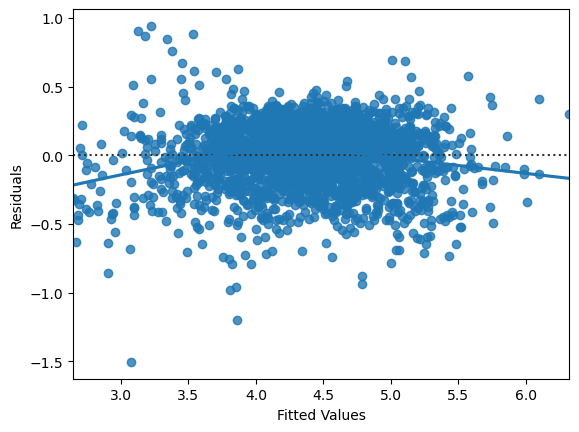

```python
# Test for Linearity and Independence
sns.residplot(data=dfsum, x='Fitted Values', y='Residuals', lowess=True);
```

The above visualization of fitted values and residuals doesn't appear to have any pattern so the test will pass.

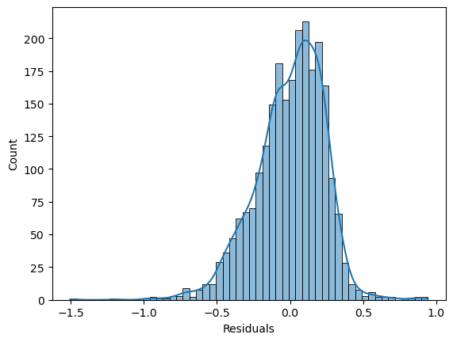

```python
# Test for Normality
sns.histplot(data=dfsum, x='Residuals', kde=True);
```

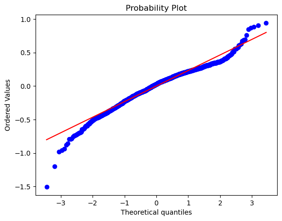

```python
# Here is a QQ Plot to test the residuals
stats.probplot(dfsum['Residuals'], dist='norm', plot=pylab);
```

```python
stats.shapiro(dfsum["Residuals"])
```

```
ShapiroResult(statistic=0.972599446773529, pvalue=4.1217707143114126e-21)
```

Per the Shapiro test above, the residuals are not strictly normal, but they are close enough to following the line on the QQ Plot that I can say the model satisfies this test.

```python
# Test of Homoscedasticity
values = ["F statistic", "p-value"]
test = sms.het_goldfeldquandt(dfsum['Residuals'], X)
lzip(values, test)
```

```
[('F statistic', 1.059596733490635), ('p-value', 0.15843126231934584)]
```

The p-value above is much greater than 0.05, so we can confidently say that the residuals are homoscedastic. The test is satisfied.

## Final Model

```python
print(olsres6.summary())
```

```
                              OLS Regression Results
=================================================================================
Dep. Variable:     normalized_used_price   R-squared:                       0.837
Model:                               OLS   Adj. R-squared:                  0.837
Method:                    Least Squares   F-statistic:                     1125.
Date:                   Tue, 10 Oct 2023   Prob (F-statistic):               0.00
Time:                           13:58:15   Log-Likelihood:                 65.901
No. Observations:                   2417   AIC:                            -107.8
Df Residuals:                       2405   BIC:                            -38.32
Df Model:                             11
Covariance Type:               nonrobust
========================================================================================
                           coef    std err          t      P>|t|      [0.025      0.975]
----------------------------------------------------------------------------------------
const                  -35.6569      7.021     -5.079      0.000     -49.425     -21.889
screen_size              0.0421      0.001     28.081      0.000       0.039       0.045
4g                       0.0434      0.015      2.897      0.004       0.014       0.073
main_camera_mp           0.0153      0.001     13.265      0.000       0.013       0.018
selfie_camera_mp         0.0134      0.001     12.659      0.000       0.011       0.016
ram                      0.0200      0.004      4.545      0.000       0.011       0.029
release_year             0.0183      0.003      5.244      0.000       0.011       0.025
normalized_new_price     0.4355      0.011     40.497      0.000       0.414       0.457
brand_name_Infinix       0.2171      0.085      2.553      0.011       0.050       0.384
brand_name_OnePlus       0.1672      0.067      2.499      0.013       0.036       0.298
brand_name_Realme        0.1932      0.047      4.114      0.000       0.101       0.285
brand_name_Xiaomi        0.1066      0.026      4.140      0.000       0.056       0.157
==============================================================================
Omnibus:                      214.305   Durbin-Watson:                   1.901
Prob(Omnibus):                  0.000   Jarque-Bera (JB):              404.045
Skew:                          -0.599   Prob(JB):                     1.83e-88
Kurtosis:                       4.605   Cond. No.                     2.95e+06
==============================================================================

Notes:
[1] Standard Errors assume that the covariance matrix of the errors is correctly specified.
[2] The condition number is large, 2.95e+06. This might indicate that there are
strong multicollinearity or other numerical problems.
```

Final model:

normalized_used_price = (0.0421 *screen_size) + (0.0434* 4g) + (0.0153 *main_camera_mp) + (0.0134* selfie_camera_mp) + (0.02 *ram) + (0.0183* release_year) + (0.4355 *normalized_new_price) + (0.2171* brand_name_Infinix) + (0.1672 *brand_name_OnePlus) + (0.1932* brand_name_Realme) + (0.1066 * brand_name_Xiaomi) - 35.6569

```python
X.columns
```

```
Index(['const', 'screen_size', '4g', 'main_camera_mp', 'selfie_camera_mp',
       'ram', 'release_year', 'normalized_new_price', 'brand_name_Infinix',
       'brand_name_OnePlus', 'brand_name_Realme', 'brand_name_Xiaomi'],
      dtype='object')
```

```python
x_test.columns
```

```
Index(['const', 'screen_size', '4g', '5g', 'main_camera_mp',
       'selfie_camera_mp', 'int_memory', 'ram', 'battery', 'weight',
       'release_year', 'days_used', 'normalized_new_price',
       'brand_name_Alcatel', 'brand_name_Apple', 'brand_name_Asus',
       'brand_name_BlackBerry', 'brand_name_Celkon', 'brand_name_Coolpad',
       'brand_name_Gionee', 'brand_name_Google', 'brand_name_HTC',
       'brand_name_Honor', 'brand_name_Huawei', 'brand_name_Infinix',
       'brand_name_Karbonn', 'brand_name_LG', 'brand_name_Lava',
       'brand_name_Lenovo', 'brand_name_Meizu', 'brand_name_Micromax',
       'brand_name_Microsoft', 'brand_name_Motorola', 'brand_name_Nokia',
       'brand_name_OnePlus', 'brand_name_Oppo', 'brand_name_Others',
       'brand_name_Panasonic', 'brand_name_Realme', 'brand_name_Samsung',
       'brand_name_Sony', 'brand_name_Spice', 'brand_name_Vivo',
       'brand_name_XOLO', 'brand_name_Xiaomi', 'brand_name_ZTE', 'os_Others',
       'os_Windows', 'os_iOS'],
      dtype='object')
```

```python
# Dropping columns in the test set that were dropped in the model
x_test2 = x_test.drop(['5g', 'int_memory', 'battery', 'weight',
       'days_used', 'brand_name_Alcatel', 'brand_name_Apple', 'brand_name_Asus',
       'brand_name_BlackBerry', 'brand_name_Celkon', 'brand_name_Coolpad',
       'brand_name_Gionee', 'brand_name_Google', 'brand_name_HTC',
       'brand_name_Honor', 'brand_name_Huawei',
       'brand_name_Karbonn', 'brand_name_LG', 'brand_name_Lava',
       'brand_name_Lenovo', 'brand_name_Meizu', 'brand_name_Micromax',
       'brand_name_Microsoft', 'brand_name_Motorola', 'brand_name_Nokia',
       'brand_name_Oppo', 'brand_name_Others',
       'brand_name_Panasonic', 'brand_name_Samsung',
       'brand_name_Sony', 'brand_name_Spice', 'brand_name_Vivo',
       'brand_name_XOLO', 'brand_name_ZTE', 'os_Others',
       'os_Windows', 'os_iOS'], axis=1)
x_test2.columns
```

```
Index(['const', 'screen_size', '4g', 'main_camera_mp', 'selfie_camera_mp',
       'ram', 'release_year', 'normalized_new_price', 'brand_name_Infinix',
       'brand_name_OnePlus', 'brand_name_Realme', 'brand_name_Xiaomi'],
      dtype='object')
```

```python
# Making model predictions on the test set
y_pred = olsres6.predict(x_test2)
```

```python
# RMSE for training data
rmse_t = np.sqrt(mean_squared_error(y, dfsum["Fitted Values"]))
rmse_t
```

```
0.2354623420932979
```

```python
# RMSE for testing data
rmse_te = np.sqrt(mean_squared_error(y_test, y_pred))
rmse_te
```

```
0.2401898409914533
```

The two RMSE values are close, indicating that the model is not overfitting the data.

```python
mae_t = mean_absolute_error(y, dfsum["Fitted Values"])
mae_t
```

```
0.18454523681750468
```

```python
mae_te = mean_absolute_error(y_test, y_pred)
mae_te
```

```
0.18470545605079108
```

The error margin is very low, which shows that the model will predict the price of a used phone within 0.18 units.